# Part II - Factors that affect a Loan's Status

## by Collins Baragbor

## Investigation Overview

I wanted to examine the variables that could impact Loan Status in this analysis. The Borrower APR, Original Loan Amount, Term, Stated Monthly Income, and Monthly Loan Payment were the key factors.

## Dataset Overview

This dataset after cleaning, contains 75173 loans with 19 variables on each loan, including loan amount, borrower rate (or interest rate), current loan status, borrower income, and many others. This [data dictionary](https://docs.google.com/spreadsheets/d/1gDyi_L4UvIrLTEC6Wri5nbaMmkGmLQBk-Yx3z0XDEtI/edit#gid=0) explains the variables in the data set.

## Distribution of Loan Status

Loan status 'current' has the highest count in the distribution.

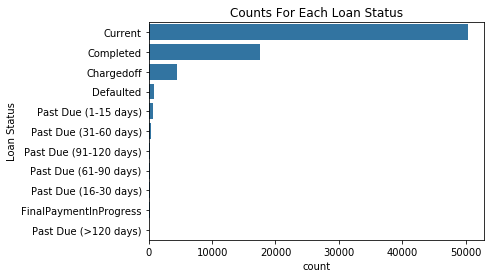

## Distribution of Borrower APR

The maximum APR for borrowers is in the range of 0.35 and 0.37. This could imply that many loans have average percentage rates of between 30% and 40%, which is quite high. And the lowest APR is just 2%. In the range of 0.16 and 0.20, there are some high bins. After 0.20, the number of APR values decreases, but from 0.26 to 0.30, APR rises once more. Then the data decreases and the APR count once more increases dramatically.

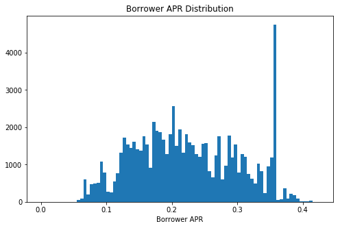

## Distribution of Original Loan Amount

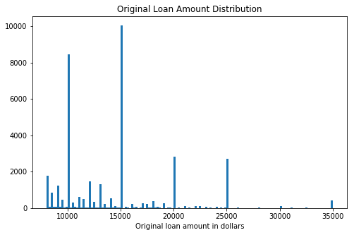

## Distribution of `LoanStatus`, `Term` and `[StatedMonthlyIncome, MonthlyLoanPayment, LoanOriginalAmount]`

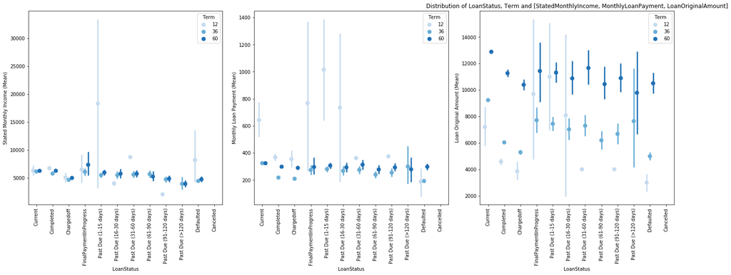